# Project Writeup - Practical Machine Learning (Coursera)

Jorge Salvador Paredes Merino

Thursday, October 25, 2014

## 1. Dataset

Source: [Human Activity Recognition (PUC-RIO)](http://groupware.les.inf.puc-rio.br/har)

[Training](http://d396qusza40orc.cloudfront.net/predmachlearn/pml-training.csv)

[Testing](http://d396qusza40orc.cloudfront.net/predmachlearn/pml-testing.csv) (evaluated by Coursera System, we dont have labels of these results)

## 2. Objectives

Predict the manner in which a group of enthusiasts who take measurements about themselves did the exercise. This is the “classe” variable in the training set. You may use any of the other variables to predict with. You should create a report describing how you built your model, how you used cross validation, what you think the expected out of sample error is, and why you made the choices you did.

You will also use your prediction model to predict 20 different test cases ([Testing](http://d396qusza40orc.cloudfront.net/predmachlearn/pml-testing.csv)). For this reason, [Training](http://d396qusza40orc.cloudfront.net/predmachlearn/pml-training.csv) will be splited to build the present Machine Learning Model in this report.

## 3. Data Processing

### 3.1. Loading or installing the required packages

In this report are used r packages:

- **mi** (to plot missing values with respect of dataset)
- **caret** (to build machine learning model)

With the following code, packages required will be loaded or installed in case you do not have them:

```r
packages = c("mi","caret")  # Here, add your required packages
ipak <- function(pkg){
  new.pkg <- pkg[!(pkg %in% installed.packages()[, "Package"])]
  if (length(new.pkg))
    install.packages(new.pkg, dependencies = TRUE)
  sapply(pkg, require, character.only = TRUE)
}

ipak(packages)
```

```
##    mi caret
##  TRUE  TRUE
```

### 3.2. Reading datasets

```r
file_training = "pml-training.csv"
file_testing = "pml-testing.csv"

training = read.csv(file_training, sep=",", header = TRUE, na.strings= c("NA",""," "), nrow=19622)
testing = read.csv(file_testing, sep=",", header = TRUE, na.strings= c("NA",""," "), nrow=20)

dim(training)
```

```
## [1] 19622   160
```

```r
dim(testing)
```

```
## [1]  20 160
```

### 3.2. Cleaning datasets

In the first instance, are removed attributes related to: timestam, X, usern_name, new_window:

```r
removeIndex = grep("timestamp|X|user_name|new_window",names(training));
training = training[,-removeIndex];
testing = testing[,-removeIndex];
```

To have a general overview about the dataset, we can take a look of missing values which are represented in red color, The folling picture (which is rotated) is a part of the dataset. Summary of the dataset is need complement the picture.

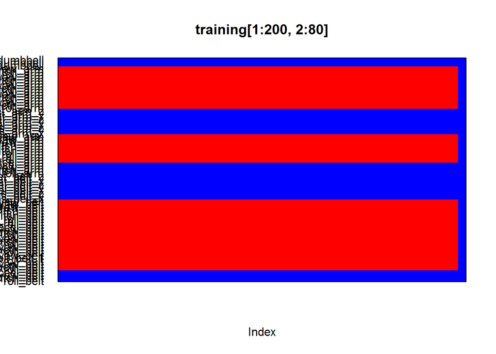

```r
missing.pattern.plot(training[1:200,2:80], ylab = "")
```

```r
summary(training)
```

```
##    num_window      roll_belt        pitch_belt          yaw_belt
##  Min.   :  1.0   Min.   :-28.90   Min.   :-55.8000   Min.   :-180.00
##  1st Qu.:222.0   1st Qu.:  1.10   1st Qu.:  1.7600   1st Qu.: -88.30
##  Median :424.0   Median :113.00   Median :  5.2800   Median : -13.00
##  Mean   :430.6   Mean   : 64.41   Mean   :  0.3053   Mean   : -11.21
##  3rd Qu.:644.0   3rd Qu.:123.00   3rd Qu.: 14.9000   3rd Qu.:  12.90
##  Max.   :864.0   Max.   :162.00   Max.   : 60.3000   Max.   : 179.00
##
##  total_accel_belt kurtosis_roll_belt kurtosis_picth_belt kurtosis_yaw_belt
##  Min.   : 0.00    #DIV/0!  :   10    #DIV/0!  :   32     #DIV/0!:  406
##  1st Qu.: 3.00    -1.908453:    2    47.000000:    4     NA's   :19216
##  Median :17.00    -0.016850:    1    -0.150950:    3
##  Mean   :11.31    -0.021024:    1    -0.684748:    3
##  3rd Qu.:18.00    -0.025513:    1    -1.750749:    3
##  Max.   :29.00    (Other)  :  391    (Other)  :  361
##                   NA's     :19216    NA's     :19216
##  skewness_roll_belt skewness_roll_belt.1 skewness_yaw_belt
##  #DIV/0!  :    9    #DIV/0!  :   32      #DIV/0!:  406
##  0.000000 :    4    0.000000 :    4      NA's   :19216
##  0.422463 :    2    -2.156553:    3
##  -0.003095:    1    -3.072669:    3
##  -0.010002:    1    -6.324555:    3
##  (Other)  :  389    (Other)  :  361
##  NA's     :19216    NA's     :19216
##  max_roll_belt     max_picth_belt   max_yaw_belt   min_roll_belt
##  Min.   :-94.300   Min.   : 3.00   -1.1   :   30   Min.   :-180.00
##  1st Qu.:-88.000   1st Qu.: 5.00   -1.4   :   29   1st Qu.: -88.40
##  Median : -5.100   Median :18.00   -1.2   :   26   Median :  -7.85
##  Mean   : -6.667   Mean   :12.92   -0.9   :   24   Mean   : -10.44
##  3rd Qu.: 18.500   3rd Qu.:19.00   -1.3   :   22   3rd Qu.:   9.05
##  Max.   :180.000   Max.   :30.00   (Other):  275   Max.   : 173.00
##  NA's   :19216     NA's   :19216   NA's   :19216   NA's   :19216
##  min_pitch_belt   min_yaw_belt   amplitude_roll_belt amplitude_pitch_belt
##  Min.   : 0.00   -1.1   :   30   Min.   :  0.000     Min.   : 0.000
##  1st Qu.: 3.00   -1.4   :   29   1st Qu.:  0.300     1st Qu.: 1.000
##  Median :16.00   -1.2   :   26   Median :  1.000     Median : 1.000
##  Mean   :10.76   -0.9   :   24   Mean   :  3.769     Mean   : 2.167
##  3rd Qu.:17.00   -1.3   :   22   3rd Qu.:  2.083     3rd Qu.: 2.000
##  Max.   :23.00   (Other):  275   Max.   :360.000     Max.   :12.000
##  NA's   :19216   NA's   :19216   NA's   :19216       NA's   :19216
```

[output cut: 297 more lines]

```
##  Min.   : -8.0900   Min.   :-498.00   Min.   :-632.0   Min.   :-446.00
##  1st Qu.: -0.1800   1st Qu.:-178.00   1st Qu.:  57.0   1st Qu.:-182.00
##  Median :  0.0800   Median : -57.00   Median : 201.0   Median : -39.00
##  Mean   :  0.1512   Mean   : -61.65   Mean   : 163.7   Mean   : -55.29
##  3rd Qu.:  0.4900   3rd Qu.:  76.00   3rd Qu.: 312.0   3rd Qu.:  26.00
##  Max.   :231.0000   Max.   : 477.00   Max.   : 923.0   Max.   : 291.00
##
##  magnet_forearm_x  magnet_forearm_y magnet_forearm_z classe
##  Min.   :-1280.0   Min.   :-896.0   Min.   :-973.0   A:5580
##  1st Qu.: -616.0   1st Qu.:   2.0   1st Qu.: 191.0   B:3797
##  Median : -378.0   Median : 591.0   Median : 511.0   C:3422
##  Mean   : -312.6   Mean   : 380.1   Mean   : 393.6   D:3216
##  3rd Qu.:  -73.0   3rd Qu.: 737.0   3rd Qu.: 653.0   E:3607
##  Max.   :  672.0   Max.   :1480.0   Max.   :1090.0
##
```

We can see many missing values with a curious pattern. Attributes which have missing values present exactly 19216 each one. If we remove registers with missing values we will suffer huge losses in information decreasing from **19622** to **406** registres.

For this reason, we only delete the column attribute which present `NA` (missing values).

```r
a = colSums(is.na(training))
c = a!= 19216 # index of attributes to be remained
filter_training = training[, c]
filter_testing = testing[, c]

summary(filter_training) #
```

```
##    num_window      roll_belt        pitch_belt          yaw_belt
##  Min.   :  1.0   Min.   :-28.90   Min.   :-55.8000   Min.   :-180.00
##  1st Qu.:222.0   1st Qu.:  1.10   1st Qu.:  1.7600   1st Qu.: -88.30
##  Median :424.0   Median :113.00   Median :  5.2800   Median : -13.00
##  Mean   :430.6   Mean   : 64.41   Mean   :  0.3053   Mean   : -11.21
##  3rd Qu.:644.0   3rd Qu.:123.00   3rd Qu.: 14.9000   3rd Qu.:  12.90
##  Max.   :864.0   Max.   :162.00   Max.   : 60.3000   Max.   : 179.00
##  total_accel_belt  gyros_belt_x        gyros_belt_y       gyros_belt_z
##  Min.   : 0.00    Min.   :-1.040000   Min.   :-0.64000   Min.   :-1.4600
##  1st Qu.: 3.00    1st Qu.:-0.030000   1st Qu.: 0.00000   1st Qu.:-0.2000
##  Median :17.00    Median : 0.030000   Median : 0.02000   Median :-0.1000
##  Mean   :11.31    Mean   :-0.005592   Mean   : 0.03959   Mean   :-0.1305
##  3rd Qu.:18.00    3rd Qu.: 0.110000   3rd Qu.: 0.11000   3rd Qu.:-0.0200
##  Max.   :29.00    Max.   : 2.220000   Max.   : 0.64000   Max.   : 1.6200
##   accel_belt_x       accel_belt_y     accel_belt_z     magnet_belt_x
##  Min.   :-120.000   Min.   :-69.00   Min.   :-275.00   Min.   :-52.0
##  1st Qu.: -21.000   1st Qu.:  3.00   1st Qu.:-162.00   1st Qu.:  9.0
##  Median : -15.000   Median : 35.00   Median :-152.00   Median : 35.0
##  Mean   :  -5.595   Mean   : 30.15   Mean   : -72.59   Mean   : 55.6
##  3rd Qu.:  -5.000   3rd Qu.: 61.00   3rd Qu.:  27.00   3rd Qu.: 59.0
##  Max.   :  85.000   Max.   :164.00   Max.   : 105.00   Max.   :485.0
##  magnet_belt_y   magnet_belt_z       roll_arm         pitch_arm
##  Min.   :354.0   Min.   :-623.0   Min.   :-180.00   Min.   :-88.800
##  1st Qu.:581.0   1st Qu.:-375.0   1st Qu.: -31.77   1st Qu.:-25.900
##  Median :601.0   Median :-320.0   Median :   0.00   Median :  0.000
##  Mean   :593.7   Mean   :-345.5   Mean   :  17.83   Mean   : -4.612
##  3rd Qu.:610.0   3rd Qu.:-306.0   3rd Qu.:  77.30   3rd Qu.: 11.200
##  Max.   :673.0   Max.   : 293.0   Max.   : 180.00   Max.   : 88.500
##     yaw_arm          total_accel_arm  gyros_arm_x        gyros_arm_y
##  Min.   :-180.0000   Min.   : 1.00   Min.   :-6.37000   Min.   :-3.4400
##  1st Qu.: -43.1000   1st Qu.:17.00   1st Qu.:-1.33000   1st Qu.:-0.8000
##  Median :   0.0000   Median :27.00   Median : 0.08000   Median :-0.2400
##  Mean   :  -0.6188   Mean   :25.51   Mean   : 0.04277   Mean   :-0.2571
##  3rd Qu.:  45.8750   3rd Qu.:33.00   3rd Qu.: 1.57000   3rd Qu.: 0.1400
##  Max.   : 180.0000   Max.   :66.00   Max.   : 4.87000   Max.   : 2.8400
##   gyros_arm_z       accel_arm_x       accel_arm_y      accel_arm_z
##  Min.   :-2.3300   Min.   :-404.00   Min.   :-318.0   Min.   :-636.00
##  1st Qu.:-0.0700   1st Qu.:-242.00   1st Qu.: -54.0   1st Qu.:-143.00
##  Median : 0.2300   Median : -44.00   Median :  14.0   Median : -47.00
##  Mean   : 0.2695   Mean   : -60.24   Mean   :  32.6   Mean   : -71.25
```

[output cut: 50 more lines]

```
##  Max.   :311.00000   Max.   :231.0000   Max.   : 477.00   Max.   : 923.0
##  accel_forearm_z   magnet_forearm_x  magnet_forearm_y magnet_forearm_z
##  Min.   :-446.00   Min.   :-1280.0   Min.   :-896.0   Min.   :-973.0
##  1st Qu.:-182.00   1st Qu.: -616.0   1st Qu.:   2.0   1st Qu.: 191.0
##  Median : -39.00   Median : -378.0   Median : 591.0   Median : 511.0
##  Mean   : -55.29   Mean   : -312.6   Mean   : 380.1   Mean   : 393.6
##  3rd Qu.:  26.00   3rd Qu.:  -73.0   3rd Qu.: 737.0   3rd Qu.: 653.0
##  Max.   : 291.00   Max.   :  672.0   Max.   :1480.0   Max.   :1090.0
##  classe
##  A:5580
##  B:3797
##  C:3422
##  D:3216
##  E:3607
##
```

```r
# Our final predictors, with them we have to build our model:
names(filter_training)
```

```
##  [1] "num_window"           "roll_belt"            "pitch_belt"
##  [4] "yaw_belt"             "total_accel_belt"     "gyros_belt_x"
##  [7] "gyros_belt_y"         "gyros_belt_z"         "accel_belt_x"
## [10] "accel_belt_y"         "accel_belt_z"         "magnet_belt_x"
## [13] "magnet_belt_y"        "magnet_belt_z"        "roll_arm"
## [16] "pitch_arm"            "yaw_arm"              "total_accel_arm"
## [19] "gyros_arm_x"          "gyros_arm_y"          "gyros_arm_z"
## [22] "accel_arm_x"          "accel_arm_y"          "accel_arm_z"
## [25] "magnet_arm_x"         "magnet_arm_y"         "magnet_arm_z"
## [28] "roll_dumbbell"        "pitch_dumbbell"       "yaw_dumbbell"
## [31] "total_accel_dumbbell" "gyros_dumbbell_x"     "gyros_dumbbell_y"
## [34] "gyros_dumbbell_z"     "accel_dumbbell_x"     "accel_dumbbell_y"
## [37] "accel_dumbbell_z"     "magnet_dumbbell_x"    "magnet_dumbbell_y"
## [40] "magnet_dumbbell_z"    "roll_forearm"         "pitch_forearm"
## [43] "yaw_forearm"          "total_accel_forearm"  "gyros_forearm_x"
## [46] "gyros_forearm_y"      "gyros_forearm_z"      "accel_forearm_x"
## [49] "accel_forearm_y"      "accel_forearm_z"      "magnet_forearm_x"
## [52] "magnet_forearm_y"     "magnet_forearm_z"     "classe"
```

```r
names(filter_testing)
```

```
##  [1] "num_window"           "roll_belt"            "pitch_belt"
##  [4] "yaw_belt"             "total_accel_belt"     "gyros_belt_x"
##  [7] "gyros_belt_y"         "gyros_belt_z"         "accel_belt_x"
## [10] "accel_belt_y"         "accel_belt_z"         "magnet_belt_x"
## [13] "magnet_belt_y"        "magnet_belt_z"        "roll_arm"
## [16] "pitch_arm"            "yaw_arm"              "total_accel_arm"
## [19] "gyros_arm_x"          "gyros_arm_y"          "gyros_arm_z"
## [22] "accel_arm_x"          "accel_arm_y"          "accel_arm_z"
## [25] "magnet_arm_x"         "magnet_arm_y"         "magnet_arm_z"
## [28] "roll_dumbbell"        "pitch_dumbbell"       "yaw_dumbbell"
## [31] "total_accel_dumbbell" "gyros_dumbbell_x"     "gyros_dumbbell_y"
## [34] "gyros_dumbbell_z"     "accel_dumbbell_x"     "accel_dumbbell_y"
## [37] "accel_dumbbell_z"     "magnet_dumbbell_x"    "magnet_dumbbell_y"
## [40] "magnet_dumbbell_z"    "roll_forearm"         "pitch_forearm"
## [43] "yaw_forearm"          "total_accel_forearm"  "gyros_forearm_x"
## [46] "gyros_forearm_y"      "gyros_forearm_z"      "accel_forearm_x"
## [49] "accel_forearm_y"      "accel_forearm_z"      "magnet_forearm_x"
## [52] "magnet_forearm_y"     "magnet_forearm_z"     "problem_id"
```

Doing this, we got a new dataset:

**New Testing** => [20x53], **problem_id** is not considered. It is used by Coursera to evaluated the prediction made by the model.

## 4. Building Train and Validation datasets

```r
set.seed(25625)

trainIndex = createDataPartition(filter_training$classe, p = .6,
                                  list = FALSE,
                                  times = 1)
train = filter_training[trainIndex, ]
validation = filter_training[-trainIndex, ]
```

## 5. Building Machine Learning Model

In this part, we will build a **Random Forest** model:

```r
trControl = trainControl(method = "cv", number = 4, allowParallel  = TRUE)

modelo_RF = train(classe ~., data = train, method="rf", trControl = trControl)
```

Evaluating the best model:

```r
validation$prediction = predict(modelo_RF$finalModel, newdata=validation)
confusionMatrix(data=validation$prediction, validation$classe)
```

```
## Confusion Matrix and Statistics
##
##           Reference
## Prediction    A    B    C    D    E
##          A 2230    5    0    0    0
##          B    2 1508    7    0    0
##          C    0    5 1361   16    0
##          D    0    0    0 1270    4
##          E    0    0    0    0 1438
##
## Overall Statistics
##
##                Accuracy : 0.995
##                  95% CI : (0.9932, 0.9965)
##     No Information Rate : 0.2845
##     P-Value [Acc > NIR] : < 2.2e-16
##
##                   Kappa : 0.9937
##  Mcnemar's Test P-Value : NA
##
## Statistics by Class:
##
##                      Class: A Class: B Class: C Class: D Class: E
## Sensitivity            0.9991   0.9934   0.9949   0.9876   0.9972
## Specificity            0.9991   0.9986   0.9968   0.9994   1.0000
## Pos Pred Value         0.9978   0.9941   0.9848   0.9969   1.0000
## Neg Pred Value         0.9996   0.9984   0.9989   0.9976   0.9994
## Prevalence             0.2845   0.1935   0.1744   0.1639   0.1838
## Detection Rate         0.2842   0.1922   0.1735   0.1619   0.1833
## Detection Prevalence   0.2849   0.1933   0.1761   0.1624   0.1833
## Balanced Accuracy      0.9991   0.9960   0.9958   0.9935   0.9986
```

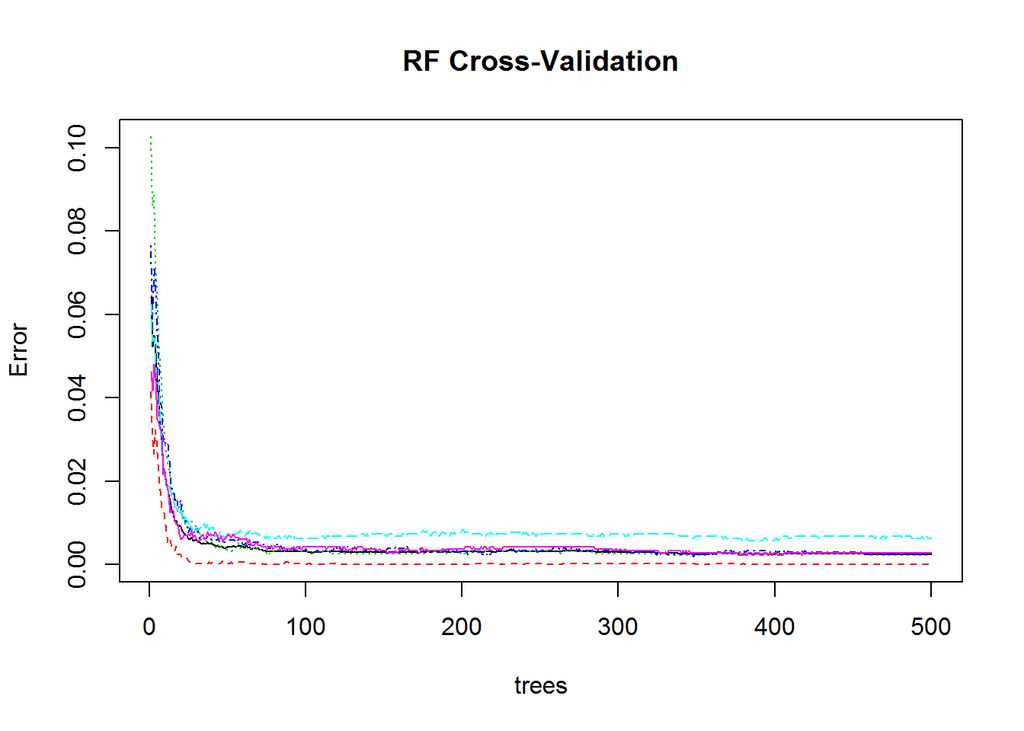

```r
plot(modelo_RF$finalModel, main="RF Cross-Validation")
```

Finally, we can look about the 20 more influencial variables in the model:

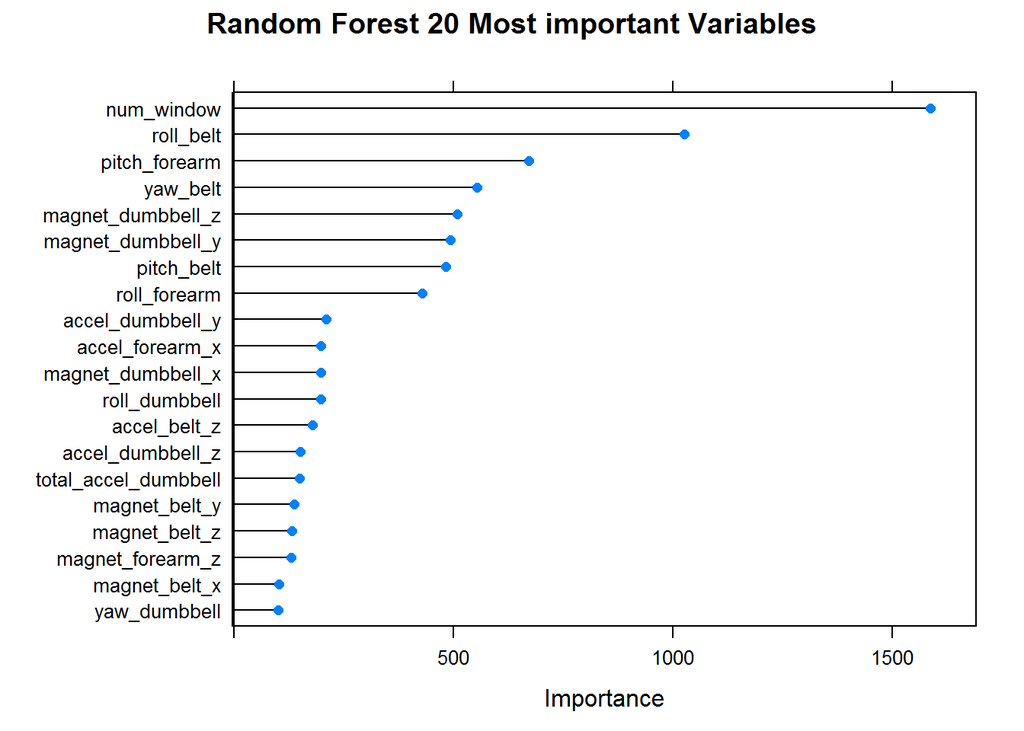

```r
RF_imp = varImp(modelo_RF, scale=FALSE)
plot(RF_imp, top=20, main='Random Forest 20 Most important Variables')
```

## 6. Predicting Testing datasets

```r
predict(modelo_RF$finalModel, newdata=filter_testing[,-54])
```

```
##  1  2  3  4  5  6  7  8  9 10 11 12 13 14 15 16 17 18 19 20
##  B  A  B  A  A  E  D  B  A  A  B  C  B  A  E  E  A  B  B  B
## Levels: A B C D E
```

## 7. Results

Evaluating the prediction of **testing dataset** (reduced into 53 predictors) the results were got 20/20 (according Coursera System). Owing to small dataset and high accuracy of the model, it is understable to get 100% of accuracy in the **test dataset**.